# Proyecto intermedio Estadística Computacional

Uriel Martínez Sánchez

2021-10-05

## Objetivo

El presente trabajo tiene como objetivo realizar un análisis exploratorio sobre la información disponible de los refugios en Nayarit en caso de algún desastre natural. Además, se pretende crear una herramienta para que los usuarios de las zonas afectadas puedan encontrar información de los refugios más cercanos a su ubicación.

## Ambiente de trabajo

Antes de comenzar el proyecto, lo primero es cargar todas las librerías necesarias para trabajar y para hacer reproducibles los resultados en cualquier otro ambiente de trabajo. Si se detecta que alguna librería no se encuentra instalada entonces se descarga. Además, se establece el directorio de trabajo como el lugar donde se encuentre guardado este archivo Rmd.

#### Librerías y directorio de trabajo

```
Las librerías a utilizar son:
 rstudioapi readxl dplyr knitr kableExtra ggplot2 tidyr
```

```
El directorio de trabajo será:
/home/uriel/itam/semestre1/estadistica_computacional/natural_disaster_project
```

#### Variables

A continuación se enlistan todas las variables definidas para el proceso ETL de creación del Data Frame. Si algún elemento cambia, se debería cambiar en esta sección.

**1) Path del excel a leer y nombre del archivo:**

**Nombre variable:** *dir.archivo*

**Valor actual :** /home/uriel/itam/semestre1/estadistica_computacional/natural_disaster_project/refugios_nayarit.xlsx

**Comentario:** Se asume que el excel a leer se encuentra en el directorio de trabajo, pero si no se encuentra aquí, sólo hay que cambiar esta variable. También se asume que el archivo se llama refugios_nayarit.xlsx, pero si también cambia, sólo hay que cambiar esta variable.

**2) Número de renglones que no se considerarán de cada hora del excel:**

**Nombre variable:** *row.skip*

**Valor actual :** 6

**Comentario:** Se asume que cada pestaña del excel a leer comienza después de 6 renglones sin información. Si este asumption cambia, sólo hay que cambiar el valor de esta variable en esta sección.

**3) Nombre y número de columnas:**

**Nombre variable:** *col.names*

**Valor actual :**

- `no`
- `refugio`
- `municipio`
- `direccion`
- `uso_inmueble`
- `servicios`
- `capacidad_personas`
- `latitud`
- `longitud`
- `altitud`
- `responsable`
- `telefono`

**Comentario:** Se asume que el Data Frame cuenta con 12 columnas ordenadas como el vector por default. Si algo cambia en el nombre, orden, o número de columnas se debe cambiar este vector. **Nota:** El excel se lee sin los nombres de campo que tiene por default

## Extracción de la información

Con la definición del ambiente de trabajo y las variables que podrían cambiar, a continuación se procedió a leer el excel a procesar para convertirlo en un Data Frame más fácil de trabajar, limpiar y procesar.

Para la carga de todas las hojas del excel, se asumen los valores de variable considerados en la sección anterior. Además, se leen todas las hojas que el excel pudiera llegar a tener.

```
El resultado es un Data Frame como el siguiente:
```

```
# A tibble: 459 × 12
      no refugio   municipio direccion  uso_inmueble servicios  capacidad_perso…
   <dbl> <chr>     <chr>     <chr>      <chr>        <chr>                 <dbl>
 1     1 PRIMARIA… ACAPONETA LOPEZ RAY… EDUCACION    AGUA, SAN…              200
 2     2 JARDIN D… ACAPONETA ALDAMA ES… EDUCACION    AGUA, SAN…              100
 3     3 PRIMARIA… ACAPONETA E. CARRAN… EDUCACION    AGUA, SAN…              200
 4     4 PRIMARIA… ACAPONETA AMADO NER… EDUCACION    AGUA, SAN…              100
 5     5 PRIMARIA… ACAPONETA VERACRUZ … EDUCACION    AGUA, SAN…              150
 6     6 PRIMARIA… ACAPONETA MORELOS Y… EDUCACION    AGUA, SAN…              200
 7     7 PRIMARIA… ACAPONETA MATAMOROS… EDUCACION    AGUA, SAN…              250
 8     8 SINDICAT… ACAPONETA QUERETARO… GREMIO SIND… AGUA, SAN…              100
 9     9 ESTADIO … ACAPONETA JUAN ESCU… DEPORTE      AGUA, SAN…              300
10    10 CASA DE … ACAPONETA MORELOS    CULTURAL     AGUA, SAN…              300
# … with 449 more rows, and 5 more variables: latitud <chr>, longitud <chr>,
#   altitud <dbl>, responsable <chr>, telefono <chr>
```

## EDA

A continuación se realizará el análisis exploratorio de la base.

#### Registros inválidos

Lo primero que se detectó es que al final de cada hoja del libro de cálculo existía un renglón con la suma de la capacidad de personas en los refugios de las hojas. Se eliminarán los registros con dicha característica.

```
Ejemplos de registros a eliminar:
```

```
# A tibble: 22 × 12
      no refugio municipio direccion uso_inmueble servicios capacidad_personas
   <dbl> <chr>   <chr>     <chr>     <chr>        <chr>                  <dbl>
 1    NA <NA>    <NA>      <NA>      <NA>         <NA>                    4280
 2    NA <NA>    <NA>      <NA>      <NA>         <NA>                    2253
 3    NA <NA>    <NA>      <NA>      <NA>         <NA>                    2147
 4    NA <NA>    <NA>      <NA>      <NA>         <NA>                    1860
 5    NA <NA>    <NA>      <NA>      <NA>         <NA>                    6745
 6    NA <NA>    <NA>      <NA>      <NA>         <NA>                    4536
 7    NA <NA>    <NA>      <NA>      <NA>         <NA>                    3346
 8    NA <NA>    <NA>      <NA>      <NA>         <NA>                    2650
 9    NA <NA>    <NA>      <NA>      <NA>         <NA>                    3132
10    NA <NA>    <NA>      <NA>      <NA>         <NA>                    1011
# … with 12 more rows, and 5 more variables: latitud <chr>, longitud <chr>,
#   altitud <dbl>, responsable <chr>, telefono <chr>
```

#### Completitud

| Columna | Missings | Missings_p |
| --- | --- | --- |
| responsable | 9 | 2.06% |
| latitud | 7 | 1.6% |
| longitud | 7 | 1.6% |
| altitud | 7 | 1.6% |
| telefono | 7 | 1.6% |
| capacidad_personas | 3 | 0.69% |
| uso_inmueble | 2 | 0.46% |
| no | 0 | 0% |
| refugio | 0 | 0% |
| municipio | 0 | 0% |
| direccion | 0 | 0% |
| servicios | 0 | 0% |

#### Coordenadas geográficas

Se eliminarán los registros que no tengan latitud o longitud, o que no tengan un valor válido, ya que son datos importantes para la ubicación del refugio más cercano. Además, la información proporcionada viene con formato de grados, minutos y segundos, por lo que las coordenadas geográficas se tranformarán a números decimales.

Finalmente, cabe comentar que se encontró que el refugio 434 tiene las coordenadas de latitud y longitud invertidas, por lo que el ETL invierte las coordenadas sólo para este refugio.

```
Ejemplos de registros sin latitud o longitud:
```

| no | refugio | municipio | direccion | uso_inmueble | servicios | capacidad_personas | latitud | longitud | altitud | responsable | telefono |
| --- | --- | --- | --- | --- | --- | --- | --- | --- | --- | --- | --- |
| 75 | ESCUELA PRIMARIA | AMATLAN DE CAÑAS | PIE DE LA CUESTA | EDUCACION | AGUA, SANITARIOS Y LUZ ELECTRICA | 50 | NA | NA | NA | PROTECCION CIVIL MPAL. | 01324-2470281 CEL. 045324-1061620 |
| 83 | HOSPITAL | AMATLAN DE CAÑAS | AMATLAN DE CAÑAS | HOSPITAL | AGUA, SANITARIOS Y LUZ ELECTRICA | 100 | NA | NA | NA | NA | NA |
| 84 | EJIDO | AMATLAN DE CAÑAS | ESTANCIA DE LOS LOPEZ | EJIDAL | AGUA, SANITARIOS Y LUZ ELECTRICA | 100 | NA | NA | NA | NA | NA |
| 283 | ESCUELA PREPARATORIA | LA YESCA | PUENTE DE CAMOTLAN | EDUCACION | AGUA, SANITARIOS Y LUZ ELECTRICA | 200 | NA | NA | NA | LAZARO AVILA IBARRA | 311-2581174 311-2581176 |
| 336 | PALACIO MUNICIPAL | JALA | HIDALGO Y ZARAGOZA | GOBIERNO MUNICIPAL | AGUA, SANITARIOS Y LUZ ELECTRICA | NA | NA | NA | NA | NA | NA |
| 337 | CENTRO SOCIAL " EL RINCON LATINO " | JALA | JUAREZ Y GUADALAJARA | NA | AGUA, SANITARIOS Y LUZ ELECTRICA | NA | NA | NA | NA | NA | NA |
| 338 | CENTRO SOCIAL " CLUB DE LEONES " | JALA | TAMPICO POR ENTRADA PRINCIPAL DEL BARRIO DE SAN FRANCISCO | NA | AGUA, SANITARIOS Y LUZ ELECTRICA | NA | NA | NA | NA | NA | NA |

```
Registro del refugio 434 (coordenadas invertidas):
```

| no | refugio | municipio | direccion | uso_inmueble | servicios | capacidad_personas | latitud | longitud | altitud | responsable | telefono |
| --- | --- | --- | --- | --- | --- | --- | --- | --- | --- | --- | --- |
| 434 | ESC. PRIM. “ADOLFO LOPEZ MATEOS” | BAHIA DE BANDERAS | MEZCALITOS | EDUCACION | AGUA, SANITARIOS Y LUZ ELECTRICA | 41 | 105º16’56.23" | 20º42’47.86" | 20 | LUIS GERARDO | PCM: 322-2976571 CEL. 322-1089481 |

#### Municipios

Los municipios con más refugios son Bahía de Banderas, Rosamorada, San Blas y Ahuacatlán.

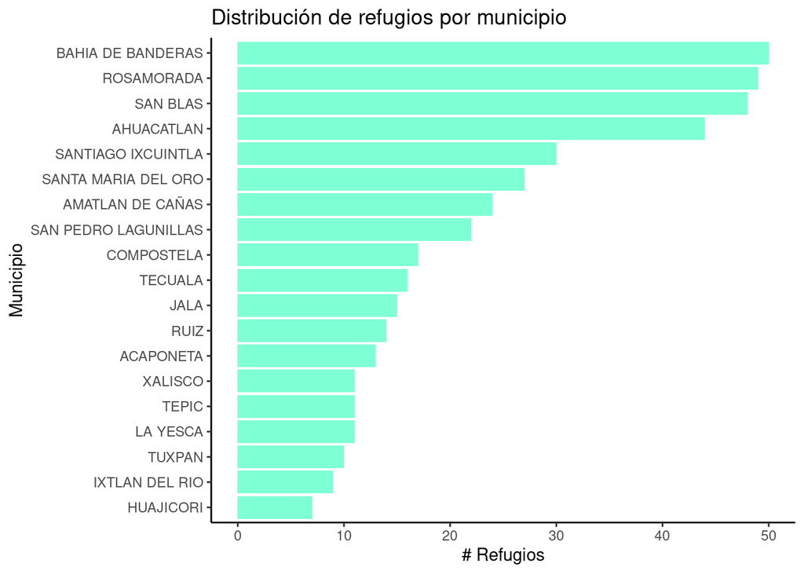

#### Uso inmueble

La mayoría de los inmuebles utilizados como refugios son escuelas como primarias y secundarias.

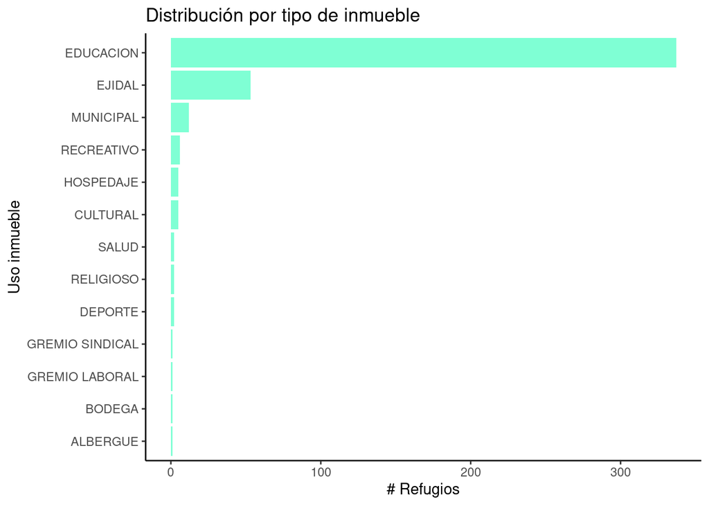

#### Servicios

Casi todos los refugios cuentan con agua, sanitarios y luz eléctrica, excepto por uno al que le faltan sanitarios.

| Servicios | Refugios |
| --- | --- |
| AGUA, SANITARIOS Y LUZ ELECTRICA | 427 |
| AGUA Y LUZ ELECTRICA | 1 |

#### Capacidad de personas

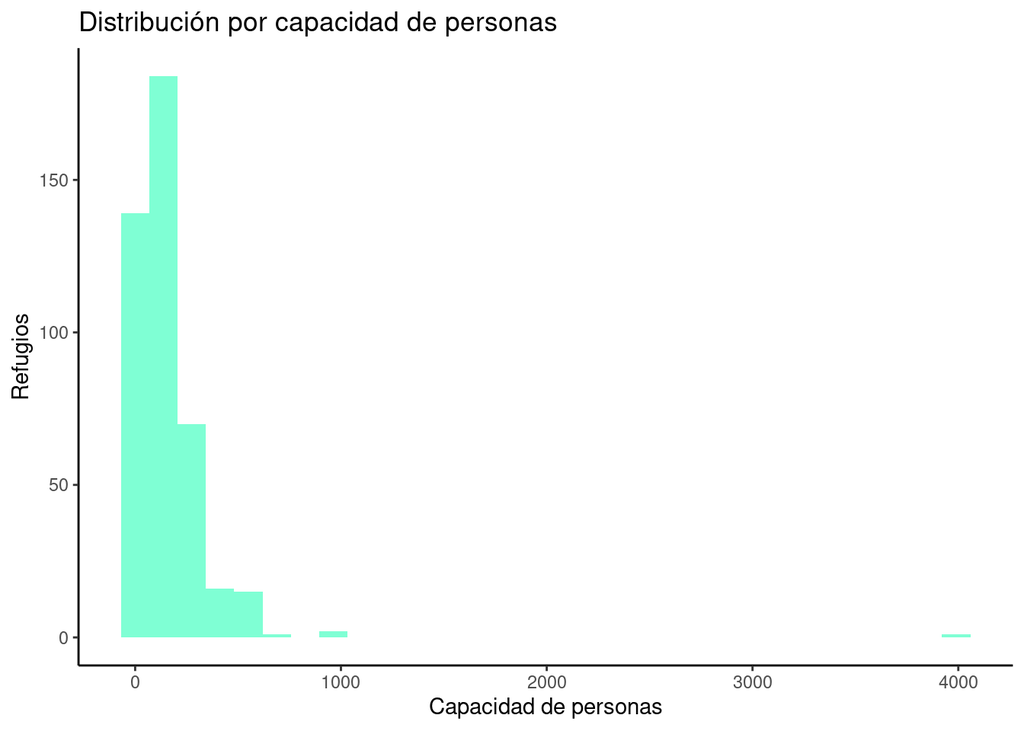

#### Teléfonos de contacto

Debido a que se detectó que había muchas formas de introducir los teléfonos de contacto, se decidió homologar el campo de la siguiente manera:

teléfono_1 // teléfono_2 // … // teléfono_n

## Data frame final

A continuación se muestra el data frame después de todos los tratamientos realizados.

| no | refugio | municipio | direccion | uso_inmueble | servicios | capacidad_personas | latitud | longitud | altitud | responsable | telefono | latitud_val | longitud_val | telefonos |
| --- | --- | --- | --- | --- | --- | --- | --- | --- | --- | --- | --- | --- | --- | --- |
| 1 | PRIMARIA LABOR Y CONSTANCIA | ACAPONETA | LOPEZ RAYON | EDUCACION | AGUA, SANITARIOS Y LUZ ELECTRICA | 200 | 22°29’56.06" | 105°21’37.27" | 29 | DIR. ENRIQUE JIMENEZ LOPEZ. | CEL.-325-105-89-02 | 22.49891 | 105.3604 | 3251058902 |
| 2 | JARDIN DE NIÑOS LUIS CASTILLO LEDON | ACAPONETA | ALDAMA ESQ CHAPULTEPEC | EDUCACION | AGUA, SANITARIOS Y LUZ ELECTRICA | 100 | 22°29’53.14" | 105°21’29.48" | 34 | MAYRA SILVIA | 325-252-11-80 | 22.49809 | 105.3582 | 3252521180 |
| 3 | PRIMARIA CARMEN SERDAN | ACAPONETA | E. CARRANZA | EDUCACION | AGUA, SANITARIOS Y LUZ ELECTRICA | 200 | 22º30’00.43" | 105°21’37.46" | 30 | MA. LOPEZ CATON | 325-251-16-40 | 22.50012 | 105.3604 | 3252511640 |
| 4 | PRIMARIA LAZARO CARDENAS | ACAPONETA | AMADO NERVO | EDUCACION | AGUA, SANITARIOS Y LUZ ELECTRICA | 100 | 22°29’27.17" | 105°21’39.68 | 30 | DIR. AZAEL AGUILAR | 325-252-17-48 | 22.49088 | 105.3610 | 3252521748 |
| 5 | PRIMARIA H. AYUNTAMIENTO 1955 | ACAPONETA | VERACRUZ No.47 | EDUCACION | AGUA, SANITARIOS Y LUZ ELECTRICA | 150 | 22º29’40.21" | 105ª21’40.23" | 30 | AURORA BARRON MEDINA | 325-251-02-82 | 22.49450 | 105.3612 | 3252510282 |
| 6 | PRIMARIA MIGUEL HIDALGO Y COSTILLA | ACAPONETA | MORELOS Y OAXACA | EDUCACION | AGUA, SANITARIOS Y LUZ ELECTRICA | 200 | 22º29’23.26" | 105ª21’41.99" | 30 | ALBERTO VILLEGAS | 325-252-09-16 | 22.48979 | 105.3617 | 3252520916 |
| 7 | PRIMARIA CENTRO ESCOLAR | ACAPONETA | MATAMOROS Y PUEBLA | EDUCACION | AGUA, SANITARIOS Y LUZ ELECTRICA | 250 | 22º29’37.31" | 105ª21’33.33" | 30 | JORGE BURGUEÑO | 325-252-01-57 | 22.49370 | 105.3593 | 3252520157 |
| 8 | SINDICATO CTM | ACAPONETA | QUERETARO Y CORONA | GREMIO SINDICAL | AGUA, SANITARIOS Y LUZ ELECTRICA | 100 | 22°29’39.32" | 105°21’46.60 | 30 | JUAN DIEGO HERRERA | PCM.-323-252-19-46 | 22.49426 | 105.3629 | 3232521946 |
| 9 | ESTADIO MUNICIPAL | ACAPONETA | JUAN ESCUTIA | DEPORTE | AGUA, SANITARIOS Y LUZ ELECTRICA | 300 | 22ª29’55.10" | 105ª21’52.29" | 30 | JOSE DOMINGO ROMERO ORTEGA | 325-2510748 | 22.49864 | 105.3645 | 3252510748 |
| 10 | CASA DE LA CULTURA | ACAPONETA | MORELOS | CULTURAL | AGUA, SANITARIOS Y LUZ ELECTRICA | 300 | 22ª29’20.78" | 105ª21’46.46" | 30 | MARIO RODRIGUEZ | PCM.-323-252-19-46 | 22.48911 | 105.3629 | 3232521946 |
| 11 | CENTRO RECREATIVO NICOLAS BRAVO | ACAPONETA | México ENTRE CORONA Y GUERRERO | RECREATIVO | AGUA, SANITARIOS Y LUZ ELECTRICA | 400 | 22ª29’39.76" | 105ª21’37.87" | 30 | BONIFACIO GUZMAN | 325-252-07-17 | 22.49438 | 105.3605 | 3252520717 |
| 12 | CENTRO RECREATIVO ASTORIA CLUB | ACAPONETA | VERACRUZ No15 | RECREATIVO | AGUA, SANITARIOS Y LUZ ELECTRICA | 400 | 22ª29’30.03" | 105ª21’39.47" | 30 |  | PCM.- 323-252-19-46 | 22.49168 | 105.3610 | 3232521946 |
| 13 | IGLESIA CRISTIANA CONGREGACIONAL | ACAPONETA | VERACRUZ No 45 | RELIGIOSO | AGUA, SANITARIOS Y LUZ ELECTRICA | 50 | 22ª29’41.60" | 105ª21’40.35" | 30 | PASTOR DE LA IGLESIA | PCM.-323-252-19-46 | 22.49489 | 105.3612 | 3232521946 |
| 14 | ESCUELA FRAY PEDRO DE GANTE | AHUACATLAN | 20 DE NOVIEMBRE | EDUCACION | AGUA, SANITARIOS Y LUZ ELECTRICA | 80 | 21ª03’06.07" | 104ª29’03.50" | 1000 | MARIA BRUNILDA BAÑUELOS | 324-241-10-69 | 21.05169 | 104.4843 | 3242411069 |
| 15 | SECUNDARIA FEDERAL REVOLUCION | AHUACATLAN | 20 DE NOVIEMBRE Y ZARAGOZA | EDUCACION | AGUA, SANITARIOS Y LUZ ELECTRICA | 250 | 21ª03’18.33" | 104ª28’56.26" | 1000 | MA DEL ROSARIO FIGUEROA | PCM.-324-241-09-86 | 21.05509 | 104.4823 | 3242410986 |
| 16 | ESCUELA JOSE MARIA MORELOS | AHUACATLAN | MORELOS Y MANUEL DOBLADO | EDUCACION | AGUA, SANITARIOS Y LUZ ELECTRICA | 200 | 21ª03’04.55" | 104ª29’12.67" | 1000 | FRANCISCO JAVIER SOJO RAMOS | PCM.- 324-241-09-86 | 21.05126 | 104.4869 | 3242410986 |
| 17 | ESCUELA PREPARATORIA No.8 | AHUACATLAN | CALLE EL SALTO | EDUCACION | AGUA, SANITARIOS Y LUZ ELECTRICA | 200 | 21ª02’57.01" | 104ª29’16.71" | 1000 | JOSE ANGEL IBARRA IBARRA | 324-241-40-92 | 21.04917 | 104.4880 | 3242414092 |
| 18 | ESCUELA PLAN DE AYALA | AHUACATLAN | OAXACA E HIDALGO | EDUCACION | AGUA, SANITARIOS Y LUZ ELECTRICA | 200 | 21ª03’02.43" | 104ª28’58.82" | 1000 | ADOLFO PEREZ MACHAIN | 324-241-03-83 | 21.05067 | 104.4830 | 3242410383 |
| 19 | UNIDAD ACADEMICA DEL SUR | AHUACATLAN | CARR A GUADALAJARA KM 153 200 | EDUCACION | AGUA, SANITARIOS Y LUZ ELECTRICA | 200 | 21ª03’28.20" | 104ª29’06.67" | 1000 | OSWALD GUADALUPE MONTAÑO | PCM.- 324-241-09-86 | 21.05783 | 104.4852 | 3242410986 |
| 20 | CLUB SOCIAL Y DEPORTIVO | AHUACATLAN | 20 DE NOVIEMBRE | DEPORTE | AGUA, SANITARIOS Y LUZ ELECTRICA | 400 | 21ª03’07.37" | 104ª29’01“57” | 1000 | RAMON ZEPEDA CRESPO | PCM.- 324-241-09-86 | 21.05205 | 104.4838 | 3242410986 |
| 21 | CASA DE LA CULTURA | AHUACATLAN | HIDALGO S/N | CULTURAL | AGUA, SANITARIOS Y LUZ ELECTRICA | 200 | 21ª03’01.70" | 104ª29’03.34" | 1000 | JUANA DE AGUIRRE NAVIDAD | PCM: 324-2410986 CEL. 324-1008914 | 21.05047 | 104.4843 | 3242410986 // 3241008914 |
| 22 | SALON EJIDAL | AHUACATLAN | MORELOS S/N | EJIDAL | AGUA, SANITARIOS Y LUZ ELECTRICA | 150 | 21ª02’56.84" | 104ª28’56.17" | 1000 | FRANCISCO IBARRA | PCM: 324-2410986 CEL. 324-1008914 | 21.04912 | 104.4823 | 3242410986 // 3241008914 |
| 23 | DIF MUNICIPAL | AHUACATLAN | MORELOS S/N | MUNICIPAL | AGUA, SANITARIOS Y LUZ ELECTRICA | 250 | 21ª02’57.03" | 104ª28’57.33" | 1000 | NORMA ALICIA DOMINGEZ | 324-2410132 | 21.04918 | 104.4826 | 3242410132 |
| 24 | ESCUELA PRIMARIA AMADO NERVO | AHUACATLAN | ZOATLAN | EDUCACION | AGUA, SANITARIOS Y LUZ ELECTRICA | 60 | 21ª01’52.14" | 104ª25’51.32 | 1000 | LETICIA LOPEZ JIMENMEZ | 311-2142276 | 21.03115 | 104.4309 | 3112142276 |
| 25 | ESC. TELESECUNDARIA FRANCISCO VILLA | AHUACATLAN | ZOATLAN | EDUCACION | AGUA, SANITARIOS Y LUZ ELECTRICA | 20 | 21ª01’52.14" | 104ª25’51.32 | 1000 | GREGORIA SOLIS CIBRIAN | 311-2142276 | 21.03115 | 104.4309 | 3112142276 |
| 26 | ESCUELA PRIMARIA EMILIA CARRANZA | AHUACATLAN | LA CIENEGA | EDUCACION | AGUA, SANITARIOS Y LUZ ELECTRICA | 40 | 21ª02’04.32 | 104ª27’04.56" | 1000 | MARIA SILVIA CARRILLO ANZALDO | PCM: 324-2410986 CEL. 324-1008914 | 21.03453 | 104.4513 | 3242410986 // 3241008914 |
| 27 | ESCUELA PRIMARIA BENITO JUAREZ | AHUACATLAN | HERIBERTO JARA | EDUCACION | AGUA, SANITARIOS Y LUZ ELECTRICA | 144 | 21ª03’07.84" | 104º31’02.32" | 1040 | JOSE MANUEL RIVERA MARMOLEJO | 324-2410691 CEL 324-1067845 | 21.05218 | 104.5173 | 3242410691 // 3241067845 |
| 28 | LOCAL DE LA HACIENDA | AHUACATLAN | HERIBERTO JARA | RECREATIVO | AGUA, SANITARIOS Y LUZ ELECTRICA | 250 | 21ª03’07.84" | 104º31’02.32" | 1040 | OCTAVIO DIAZ | 324-2410722 | 21.05218 | 104.5173 | 3242410722 |
| 29 | ESC. TELESECUNDARIA VALENTIN GOMEZ FARIAS | AHUACATLAN | HERIBERTO JARA | EDUCACION | AGUA, SANITARIOS Y LUZ ELECTRICA | 40 | 21ª03’07.84" | 104º31’02.32" | 1040 | EDELMIRA GARCIA MONROY | 324-2410722 | 21.05218 | 104.5173 | 3242410722 |
| 30 | ESCUELA PRIMARIA CURSOS COMUNITARIOS | AHUACATLAN | LOS COPALES | EDUCACION | AGUA, SANITARIOS Y LUZ ELECTRICA | 15 | 21ª03’48.03" | 104ª31’52.17" | 980 | TERESA DE JESUS RASURA MEZA | PCM: 324-2410986 CEL. 324-1008914 | 21.06334 | 104.5312 | 3242410986 // 3241008914 |

[output cut: 398 more lines]

| Columna | Missings | Missings_p |
| --- | --- | --- |
| no | 0 | 0% |
| refugio | 0 | 0% |
| municipio | 0 | 0% |
| direccion | 0 | 0% |
| uso_inmueble | 0 | 0% |
| servicios | 0 | 0% |
| capacidad_personas | 0 | 0% |
| latitud | 0 | 0% |
| longitud | 0 | 0% |
| altitud | 0 | 0% |
| responsable | 0 | 0% |
| telefono | 0 | 0% |
| latitud_val | 0 | 0% |
| longitud_val | 0 | 0% |
| telefonos | 0 | 0% |